# Tutorial for `kdensity`

Jonas Moss

2025-03-04

# Basic usage

`kdensity` is called using a syntax similar to `stats::density`, but with some additional arguments. A call to `kdensity` returns a density function (with class `kdensity`), which can be used as ordinary `R`-functions.

```r
library("kdensity")
kde <- kdensity(mtcars$mpg, start = "gumbel", kernel = "gaussian")
kde(20)
```

```
#> [1] 0.06829002
```

Hence it can be used to calculate functionals, such as the expectation.

```r
integrate(function(x) x * kde(x), lower = -Inf, upper = Inf)$value
```

```
#> [1] 20.15896
```

Plotting works as with `stats::density`. If `kdensity` was called with a parametric start, use `plot_start = TRUE` inside a plotting function in order to plot the estimated parametric start density instead of the kernel density.

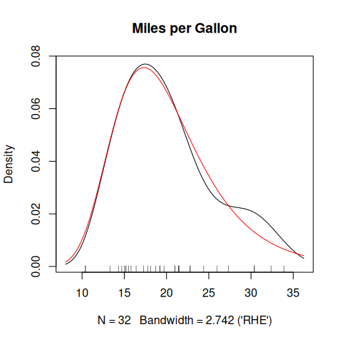

```r
plot(kde, main = "Miles per Gallon")
lines(kde, plot_start = TRUE, col = "red")
rug(mtcars$mpg)
```

If the R-package `magrittr` is installed, you can use pipes to plot.

```r
library("magrittr")
kde %>%
  plot(main = "Miles per Gallon") %>%
  lines(plot_start = TRUE, col = "red")
```

The generics `coef`, `logLik`, `AIC` and `BIC` are supported, but work only on the parametric start.

```r
coef(kde)
```

```
#> Maximum likelihood estimates for the Gumbel model
#>     mu   sigma
#> 17.321   4.865
```

```r
logLik(kde)
```

[output not shown]

```r
AIC(kde)
```

[output not shown]

To view information about the kernel density, use the `summary` generic.

```r
summary(kde)
```

```
#>
#> Call:
#> kdensity(x = mtcars$mpg, kernel = "gaussian", start = "gumbel")
#>
#> Data:        mtcars$mpg (32 obs.)
#> Bandwidth:   2.742 ('RHE')
#> Support:     (-Inf, Inf)
#> Kernel:      gaussian
#> Start:       gumbel
#> Range:       (10.4, 33.9)
#> NAs in data: FALSE
#> Adjustment:  1
#>
#> Parameter estimates:
#> mu: 17.32
#> sigma: 4.865
```

Access members of the kernel density with `$` or `[[`.

```r
kde$start_str
```

```
#> [1] "gumbel"
```

```r
kde[["x"]]
```

```
#>  [1] 21.0 21.0 22.8 21.4 18.7 18.1 14.3 24.4 22.8 19.2 17.8 16.4 17.3 15.2 10.4
#> [16] 10.4 14.7 32.4 30.4 33.9 21.5 15.5 15.2 13.3 19.2 27.3 26.0 30.4 15.8 19.7
#> [31] 15.0 21.4
```

To make changes to the kernel density estimator, you can use the generic `update` function, replace values with `$`, or make a new one.

```r
kde$bw <- "RHE"
update(kde, start = "normal")
```

`kdensity` supports all parametric starts implemented by the package `univariateML`. See [its Github page](https://github.com/JonasMoss/univariateML) for a complete list, or take a look at `univariateML::univariateML_models`.

# Custom densities and kernels

## Parametric starts

You must supply two functions and one vector to `kdensity` in order to use a custom parametric start. The first is a `density` function, the second is a function that estimates the named parameters of the density, and the third is the support of the density.

```r
normal <- list(
  density = dnorm,
  estimator = function(data) {
    c(
      mean = mean(data),
      sd = sd(data)
    )
  },
  support = c(-Inf, Inf)
)
```

The density function must take the data as its first argument, and all its parameters must be named. In addition, the function `estimator` must return a vector containing named parameters that partially match the parameter names of the density function. For instance, the arguments of `dnorm` are `x, mean, sd, log`, where `log = TRUE` means that the logarithm of the density is returned. Since `estimator` returns a named vector with names `mean` and `sd`, the names are completely matched.

The estimator function doesn’t need to be simple, as the next example shows.

### Example: A skew hyperbolic t-distribution start

The built-in data set `LakeHuron` contains annual measurements of the water level of Lake Huron from 1875 to 1972, measured in feet. We will take a look at the distribution of differences in water level across two consecutive years. Since the data are supported on the real line and there is no good reason to assume anything else, we will use a normal start.

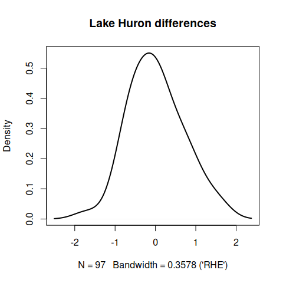

```r
LH <- diff(LakeHuron)
kde_normal <- kdensity(LH, start = "normal")
plot(kde_normal,
  lwd = 2, col = "black",
  main = "Lake Huron differences"
)
```

The density is clearly non-normal. Still, it looks fairly regular, and it should be possible to model it parametrically with some success. One of many parametric families of distributions more flexible than the normal family is the *skew hyperbolic t-distribution*, which is implemented in the `R` package `SkewHyperbolic`. This package contains the density function `dskewhyp` and a maximum likelihood estimating function in `skewhypFit`. Using these functions, we make the following list:

```r
skew_hyperbolic <- list(
  density = SkewHyperbolic::dskewhyp,
  estimator = function(x) {
    SkewHyperbolic::skewhypFit(x, printOut = FALSE)$param
  },
  support = c(-Inf, Inf)
)
```

Now we are ready to run `kdensity` and do some plotting. Note the `plot` option `plot_start = TRUE`. With this option on, the estimated parametric density is plotted without any non-parametric correction.

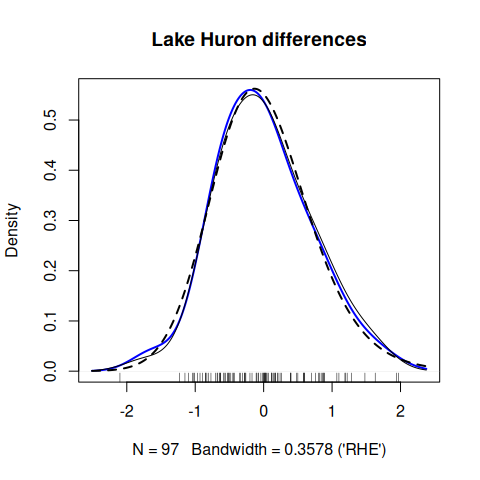

```r
kde_skewhyp <- kdensity(LH, start = skew_hyperbolic)
plot(kde_skewhyp,
  lwd = 2, col = "blue",
  main = "Lake Huron differences"
)
lines(kde_normal)
lines(kde_skewhyp, plot_start = TRUE, lty = 2, lwd = 2)
rug(LH)
```

Since all the curves are in agreement, kernel density estimation appears to add unnecessary complexity without sufficient compensation in fit. We are justified in using the skew hyperbolic t-distribution if this simplifies our analysis down the line.

## Kernels

If you want to make custom kernel, you will need to supply the kernel function, with arguments `y, x, h`. Here `x` is the random data you put into `kdensity`, `h` is the final bandwidth, and `y` is the point you want to evaluate at. The kernel is called as `1/h*kernel(y, x, h)`, and should be able to take vector inputs `x` and `y`. In addition to the kernel function, you must supply a `support` argument, which states the domain of definition of the kernel. For instance, the `gcopula` kernel is defined on `c(0, 1)`. In addition, you can optionally supply the standard deviation of the kernel. This is only used for symmetric kernels, and is useful since it makes them comparable. For example, the implementation of the `gaussian` kernel is

```r
gaussian <- list(
  kernel  = function(y, x, h) dnorm((y - x) / h),
  sd      = 1,
  support = c(-Inf, Inf)
)
```

Custom kernels can be complicated, and do not have to be symmetric.